# R Stats 4 nOObs - PMCB Retreat 2016

September 24, 2016

## Before we begin

- Download R Studio
  - https://www.rstudio.com/products/rstudio/download3/
- Go to our Github page:
  - https://github.com/daniellecrobinson/Rstats_4_n00bs

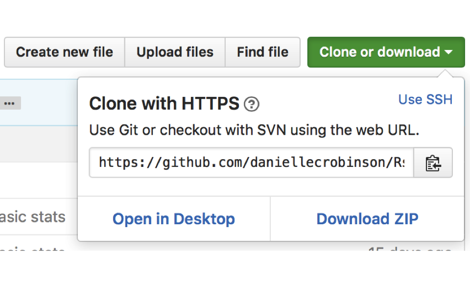

- Click on "Clone or Download"
- Click on "Download Zip"

## Why should you use R??

- Collaborative
- Free!
  - unlike Prism, for example
- Can be opened/used on any computer
- You have a ton of control over what you want to do
  - unlike Excel, for example

## Basics (1)

- use # to comment
- "**<-**" assigns values to a variable

```r
x<-1
x
```

```
## [1] 1
```

- functions ()

```r
print(x)
```

```
## [1] 1
```

## Basics (2)

- help() and ?
- in R console, use up arrow to re-type what you just wrote
- variable names can't start with a number
  - eg Data1 not 1Data
- throwing errors is normal! You will create errors *a lot*

### R is *stupid* and only knows what *you* input

## This is what R Studio looks like:

[figure not shown]

## Resources

- CRAN: https://cran.r-project.org
- http://stackoverflow.com - like google for coding questions
- R Markdown cheat sheets (rmarkdown.rstudio.com)
- Ted Laderas' R bootcamp: https://github.com/laderast/r-bootcamp
- Mozilla study groups: https://github.com/mozillascience/studyGroupLessons/issues
- R Open Sci (https://ropensci.org)
- R meetup groups (https://www.meetup.com/portland-r-user-group/)
- additional plotting abilities with ggplot package (we're not going into this)

## Fun Events:

[figure not shown]

## Fun Events:

[figure not shown]

## Let's go!

From the Github downloaded files, open:

- "example_lengths_for_R.csv"
- "BasicStatsCode.pdf"

We'll start with "BasicStatsCode.pdf"

### *PLEASE ASK US IF YOU ARE CONFUSED! :-)*

~Use your **yellow** sticky note for "confused" and **green** for "ok"~